# LABORATORIO 1 - TEXT MINING & IMAGE RECOGNITION

## JESSICA MARISOL CASTELLANOS MARTÍNEZ - 24000218

#### Problema 1:

Desarrolle una funci´on la cual reciba dos par´ametros, una imagen y un entero llamado color, la funci´on debe devolver una imagen la cual tenga activos los canales de color seg´un los siguientes puntos: Si el par´ametro color vale 1, la imagen debe mostrar activos ´unicamente el color azul. Si el par´ametro color vale 2, la imagen debe mostrar activos ´unicamente el color verde. Si el par´ametro color vale 3, la imagen debe mostrar activos ´unicamente el color rojo. Si el par´ametro color vale 10, la imagen debe mostrar activos ´unicamente los colores rojo y verde. Si el par´ametro color vale 20, la imagen debe mostrar activos ´unicamente los colores verde y azul. Si el par´ametro color vale 30, la imagen debe mostrar activos ´unicamente los colores azul y rojo

[figure not shown]

[figure not shown]

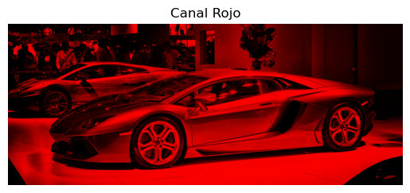

[figure not shown]

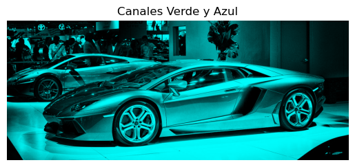

[figure not shown]

```python
import cv2
import numpy as np
import matplotlib.pyplot as plt

def activar_canales(imagen, color):
    # Crear una imagen vacía con 3 canales
    imagen_color = np.zeros((imagen.shape[0], imagen.shape[1], 3), dtype=np.uint8)

    # Activar canales de color según el valor de 'color'
    if color == 1:
        # Activar solo el canal azul
        imagen_color[:, :, 0] = imagen
    elif color == 2:
        # Activar solo el canal verde
        imagen_color[:, :, 1] = imagen
    elif color == 3:
        # Activar solo el canal rojo
        imagen_color[:, :, 2] = imagen
    elif color == 10:
        # Activar solo los canales rojo y verde
        imagen_color[:, :, 1] = imagen
        imagen_color[:, :, 2] = imagen
    elif color == 20:
        # Activar solo los canales verde y azul
        imagen_color[:, :, 0] = imagen
        imagen_color[:, :, 1] = imagen
    elif color == 30:
        # Activar solo los canales azul y rojo
        imagen_color[:, :, 0] = imagen
        imagen_color[:, :, 2] = imagen

    return imagen_color

# Prueba con imagen en escala de grises
imagen_prueba = cv2.imread('carro.jpg', cv2.IMREAD_GRAYSCALE)

# Activar canales de color según el valor del parámetro 'color'
imagen_color_1 = activar_canales(imagen_prueba, 1)
imagen_color_2 = activar_canales(imagen_prueba, 2)
imagen_color_3 = activar_canales(imagen_prueba, 3)
imagen_color_10 = activar_canales(imagen_prueba, 10)
imagen_color_20 = activar_canales(imagen_prueba, 20)
imagen_color_30 = activar_canales(imagen_prueba, 30)

# Mostrar las imágenes resultantes en el notebook
def mostrar_imagen(imagen, titulo):
    plt.imshow(cv2.cvtColor(imagen, cv2.COLOR_BGR2RGB))
    plt.title(titulo)
    plt.axis('off')
    plt.show()

mostrar_imagen(imagen_color_1, 'Canal Azul')
mostrar_imagen(imagen_color_2, 'Canal Verde')
mostrar_imagen(imagen_color_3, 'Canal Rojo')
mostrar_imagen(imagen_color_10, 'Canales Rojo y Verde')
mostrar_imagen(imagen_color_20, 'Canales Verde y Azul')
mostrar_imagen(imagen_color_30, 'Canales Azul y Rojo')
```

#### Problema 2:

En el .zip del laboratorio se le comparti´o un conjunto de imagenes en escala de grises (imagen1, imagen2, perro) estas im´agenes fueron creadas utilizando una escala de grises en 3D, cree una funcion que dadas las 3 im´agenes se construya la imagen original a color.

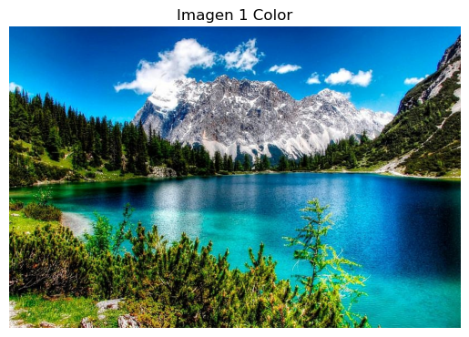

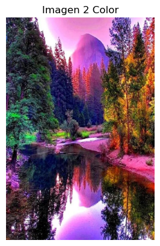

[figure not shown]

```python
import cv2
import numpy as np
import matplotlib.pyplot as plt

def reconstruir_imagen_color(imagen_azul, imagen_verde, imagen_rojo):

    if imagen_azul.shape != imagen_verde.shape or imagen_azul.shape != imagen_rojo.shape:
        raise ValueError("Las imágenes deben tener el mismo tamaño")

    # Combinar
    imagen_color = np.zeros((imagen_azul.shape[0], imagen_azul.shape[1], 3), dtype=np.uint8)
    imagen_color[:, :, 0] = imagen_azul
    imagen_color[:, :, 1] = imagen_verde
    imagen_color[:, :, 2] = imagen_rojo

    return imagen_color

# Cargar las imágenes en escala de grises
imagen1_azul = cv2.imread('imagen1_salida_gray_azul.jpg', cv2.IMREAD_GRAYSCALE)
imagen1_verde = cv2.imread('imagen1_salida_gray_verde.jpg', cv2.IMREAD_GRAYSCALE)
imagen1_rojo = cv2.imread('imagen1_salida_gray_rojo.jpg', cv2.IMREAD_GRAYSCALE)

imagen2_azul = cv2.imread('imagen2_salida_gray_azul.jpg', cv2.IMREAD_GRAYSCALE)
imagen2_verde = cv2.imread('imagen2_salida_gray_verde.jpg', cv2.IMREAD_GRAYSCALE)
imagen2_rojo = cv2.imread('imagen2_salida_gray_rojo.jpg', cv2.IMREAD_GRAYSCALE)

perro_azul = cv2.imread('perro_salida_gray_azul.jpg', cv2.IMREAD_GRAYSCALE)
perro_verde = cv2.imread('perro_salida_gray_verde.jpg', cv2.IMREAD_GRAYSCALE)
perro_rojo = cv2.imread('perro_salida_gray_rojo.jpg', cv2.IMREAD_GRAYSCALE)

# Reconstruir las imágenes a color
imagen1_color = reconstruir_imagen_color(imagen1_azul, imagen1_verde, imagen1_rojo)
imagen2_color = reconstruir_imagen_color(imagen2_azul, imagen2_verde, imagen2_rojo)
perro_color = reconstruir_imagen_color(perro_azul, perro_verde, perro_rojo)

# Resultado
def mostrar_imagen(imagen, titulo):
    plt.imshow(cv2.cvtColor(imagen, cv2.COLOR_BGR2RGB))
    plt.title(titulo)
    plt.axis('off')
    plt.show()

mostrar_imagen(imagen1_color, 'Imagen 1 Color')
mostrar_imagen(imagen2_color, 'Imagen 2 Color')
mostrar_imagen(perro_color, 'Perro Color')
```

#### Problema 3:

Cree una funci´on que dada una imagen cree una escala de grises en tres dimensiones, tome en cuenta que su funci´on debe crear 3 im´agenes como salida. Para entregar este ejercicio debe incluir una las im´agenes que haya utilizado como prueba y el resultado de las misma, no puede utilizar la imagen del Problema #2.

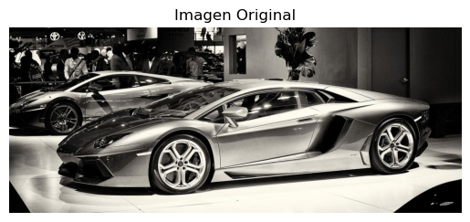

[figure not shown]

[figure not shown]

[figure not shown]

```python
import cv2
import numpy as np
import matplotlib.pyplot as plt

def crear_escala_grises_3d(imagen):
    # Separar los canales de la imagen
    azul, verde, rojo = cv2.split(imagen)

    # Crear tres imágenes en escala de grises en tres dimensiones
    imagen_gris_azul = np.zeros_like(imagen)
    imagen_gris_azul[:, :, 0] = azul

    imagen_gris_verde = np.zeros_like(imagen)
    imagen_gris_verde[:, :, 1] = verde

    imagen_gris_rojo = np.zeros_like(imagen)
    imagen_gris_rojo[:, :, 2] = rojo

    return imagen_gris_azul, imagen_gris_verde, imagen_gris_rojo

def mostrar_imagen(imagen, titulo):
    plt.imshow(cv2.cvtColor(imagen, cv2.COLOR_BGR2RGB))
    plt.title(titulo)
    plt.axis('off')
    plt.show()

ruta_imagen = 'carro.jpg'

# Cargar la imagen de prueba en color
imagen_prueba = cv2.imread(ruta_imagen)

# Crear escala de grises en tres dimensiones
imagen_gris_azul, imagen_gris_verde, imagen_gris_rojo = crear_escala_grises_3d(imagen_prueba)

# Carros
mostrar_imagen(imagen_prueba, 'Imagen Original')
mostrar_imagen(imagen_gris_azul, 'Escala de Grises Canal Azul')
mostrar_imagen(imagen_gris_verde, 'Escala de Grises Canal Verde')
mostrar_imagen(imagen_gris_rojo, 'Escala de Grises Canal Rojo')
```

#### Problema 4:

Cree una funci´on que dada una imagen, muestre el histograma de cada canal de color y el de escala de grises (utilice un promedio aritm´etico para su escala de grises, no puede usar funciones de opencv), sus histogramas deben incluir una l´ınea vertical la cual muestre el valor de la media de la distribuci´on

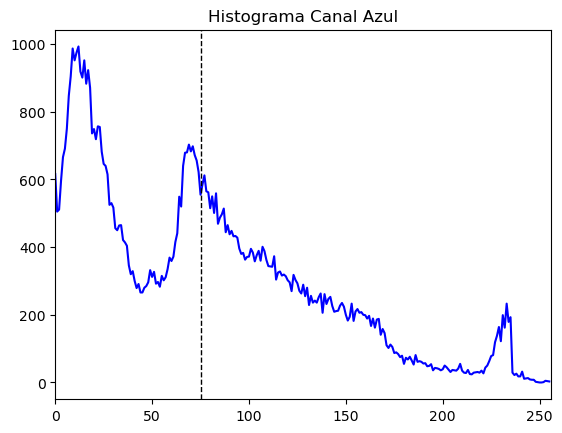

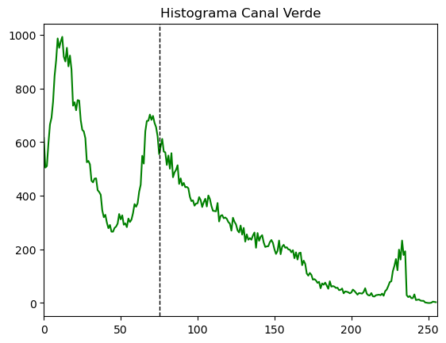

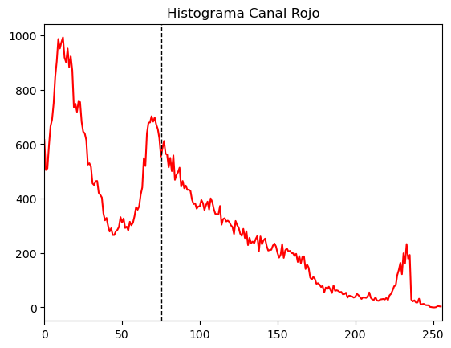

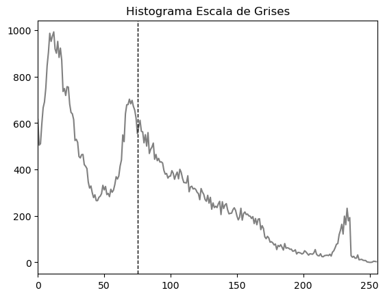

```python
import cv2
import numpy as np
import matplotlib.pyplot as plt

def calcular_histograma(imagen, canal, color, titulo):
    hist, bins = np.histogram(canal.flatten(), bins=256, range=[0,256])
    plt.plot(hist, color=color)
    plt.xlim([0,256])
    plt.title(titulo)

    # Calcular y mostrar la línea de la media
    media = np.mean(canal)
    plt.axvline(x=media, color='k', linestyle='--', linewidth=1)
    plt.show()

def mostrar_histogramas(imagen):
    # Separar los canales de la imagen
    azul, verde, rojo = cv2.split(imagen)

    # Calcular escala de grises como el promedio aritmético de los tres canales
    gris = (azul.astype(np.float32) + verde.astype(np.float32) + rojo.astype(np.float32)) / 3
    gris = gris.astype(np.uint8)

    # Mostrar histogramas de los canales y de la escala de grises
    calcular_histograma(imagen, azul, 'blue', 'Histograma Canal Azul')
    calcular_histograma(imagen, verde, 'green', 'Histograma Canal Verde')
    calcular_histograma(imagen, rojo, 'red', 'Histograma Canal Rojo')
    calcular_histograma(imagen, gris, 'gray', 'Histograma Escala de Grises')

ruta_imagen = 'perro_salida_gray_azul.jpg'

# Cargar la imagen de prueba en color
imagen_prueba = cv2.imread(ruta_imagen)

# Mostrar los histogramas de los canales y de la escala de grises
mostrar_histogramas(imagen_prueba)
```

#### Problema 5:

Investigue en que consiste el enfoque de escala de grises ponderado, luego de esto implemente una funci´on que dada una imagen, realice una escala de grises ponderada (notar que no existe una soluci´on ´unica).

[figure not shown]

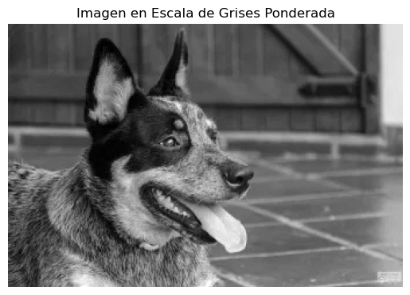

```python
import cv2
import numpy as np
import matplotlib.pyplot as plt

def escala_grises_ponderada(imagen):
    # Separar los canales de la imagen
    azul, verde, rojo = cv2.split(imagen)

    # Calcular la escala de grises ponderada
    gris_ponderado = 0.299 * rojo + 0.587 * verde + 0.114 * azul
    gris_ponderado = gris_ponderado.astype(np.uint8)

    return gris_ponderado

def mostrar_imagen(imagen, titulo):
    plt.imshow(cv2.cvtColor(imagen, cv2.COLOR_BGR2RGB))
    plt.title(titulo)
    plt.axis('off')
    plt.show()

def mostrar_imagen_gris(imagen, titulo):
    plt.imshow(imagen, cmap='gray')
    plt.title(titulo)
    plt.axis('off')
    plt.show()

# Ruta de la imagen de prueba
ruta_imagen = 'perro_color.jpg'

# Cargar la imagen de prueba en color
imagen_prueba = cv2.imread(ruta_imagen)

# Convertir la imagen a escala de grises ponderada
imagen_gris_ponderada = escala_grises_ponderada(imagen_prueba)

# Imagen original e imagen en escala de grises ponderada
mostrar_imagen(imagen_prueba, 'Imagen Original')
mostrar_imagen_gris(imagen_gris_ponderada, 'Imagen en Escala de Grises Ponderada')
```

#### Problema 6:

Investigue brevemente en que consiste el espacio de color HSV y como se mapean colores a dicho espacio, para entregar este ejercicio puede hacerlo por medio de Markdown en el mismo Notebook donde trabaj´o los dem´as ejercicios.

##### El espacio de color HSV (Hue, Saturation, Value)

es una representación alternativa al espacio de color RGB (Red, Green, Blue). Fue diseñado para ser más intuitivo para los humanos, ya que separa la información de la imagen en tres componentes:

Hue (Matiz): Representa el color puro, es decir, la longitud de onda dominante de la luz. El matiz se mide en grados en un círculo de color (0° a 360°). Por ejemplo, 0° es rojo, 120° es verde y 240° es azul.

Saturation (Saturación): Representa la intensidad o pureza del color. Va de 0 a 1, donde 0 significa un tono de gris sin color (blanco, negro o gris) y 1 es el color completamente saturado.

Value (Valor o Brillo): Representa la luminosidad del color. Va de 0 a 1, donde 0 es completamente negro y 1 es el color con su máxima intensidad.

##### Mapeo de colores al espacio HSV

El mapeo de colores desde el espacio RGB al espacio HSV implica convertir las tres componentes de color (rojo, verde y azul) en las tres componentes de HSV (matiz, saturación y valor). Este proceso implica cálculos matemáticos que transforman las coordenadas del cubo RGB al cilindro HSV.

La fórmula para la conversión es compleja y varía según los valores relativos de los componentes RGB. En términos generales, la conversión se realiza de la siguiente manera:

Hue (H): Se calcula utilizando las diferencias entre los componentes RGB. La fórmula depende del valor máximo y mínimo de los componentes R, G, y B. Saturation (S): Se calcula como la diferencia relativa entre el valor máximo y el valor mínimo de los componentes RGB. Value (V): Es simplemente el valor máximo de los componentes R, G y B.

[figure not shown]

```python
import cv2
import matplotlib.pyplot as plt

# Ruta
ruta_imagen = 'saturada.jpg'

# Cargar la imagen de prueba en color
imagen_rgb = cv2.imread(ruta_imagen)

# Convertir la imagen del espacio de color RGB al espacio HSV
imagen_hsv = cv2.cvtColor(imagen_rgb, cv2.COLOR_BGR2HSV)

# Mostrar ambas
plt.figure(figsize=(10, 5))

plt.subplot(1, 2, 1)
plt.imshow(cv2.cvtColor(imagen_rgb, cv2.COLOR_BGR2RGB))
plt.title('Imagen Original (RGB)')
plt.axis('off')

plt.subplot(1, 2, 2)
plt.imshow(cv2.cvtColor(imagen_hsv, cv2.COLOR_HSV2RGB))
plt.title('Imagen en Espacio HSV')
plt.axis('off')

plt.show()
```